# hw_002.STAT545

```r
library(gapminder)
library(tidyverse)
```

# 2. Exloring the gapminder object:

## 2.1 Checking the structure of the dataset:

```r
typeof(gapminder)
```

```
## [1] "list"
```

## 2.2 Checking the class of the dataset:

```r
class(gapminder)
```

```
## [1] "tbl_df"     "tbl"        "data.frame"
```

## 2.3 Determine the number of rows of data in the dataset:

```r
nrow(gapminder)
```

```
## [1] 1704
```

## 2.4 Determine the dimensions of the dataset:

```r
dim(gapminder)
```

```
## [1] 1704    6
```

## 2.5 Determine the data type of each variable in the dataset:

The dataset documents the population (pop), life expectancy (lifeExp), and GDP per capita (gdpPercapita) for various countries and continents from 1952-2007. Population, life expectancy, GDP per capita, and year are all quantitative variables, whereas country and continent are categorical variables.

# 3. Explore at least one quantitative and one categorical variable from the dataset.

Quantitative var=gdpPercap, categorical var=continent

## 3.1 Find the min, max, med, mean, 1st quartile, and 3rd quartile of the quantitative variable and visualize the spread of the data in context of the categorical variable.

```r
summary(gapminder$gdpPercap)
```

```
##     Min.  1st Qu.   Median     Mean  3rd Qu.     Max.
##    241.2   1202.1   3531.8   7215.3   9325.5 113523.1
```

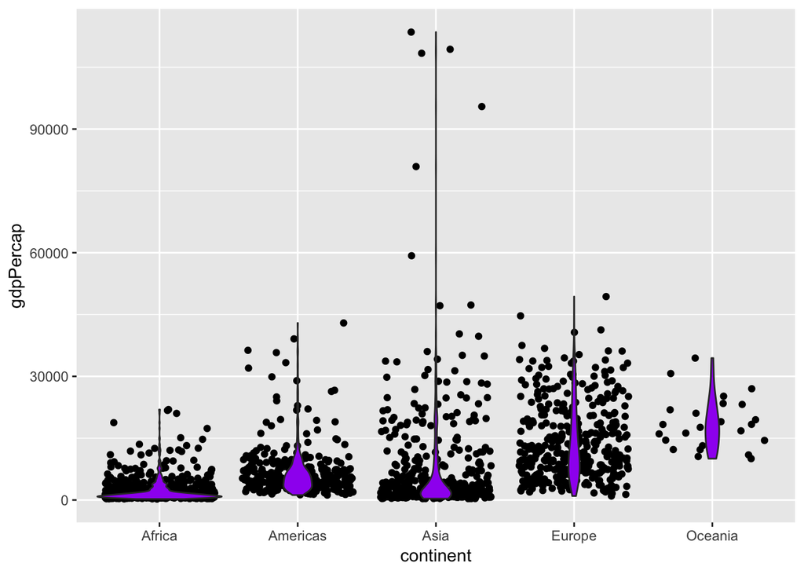

```r
ggplot(gapminder, aes(continent, gdpPercap)) +
  geom_jitter() +
  geom_violin(fill = "purple")
```

## 3.2 Create a few plots of various variables in the dataset and explore the `filter` command.

Boxplot of populations by continent with jitter plot (alpha=.1) overtop.

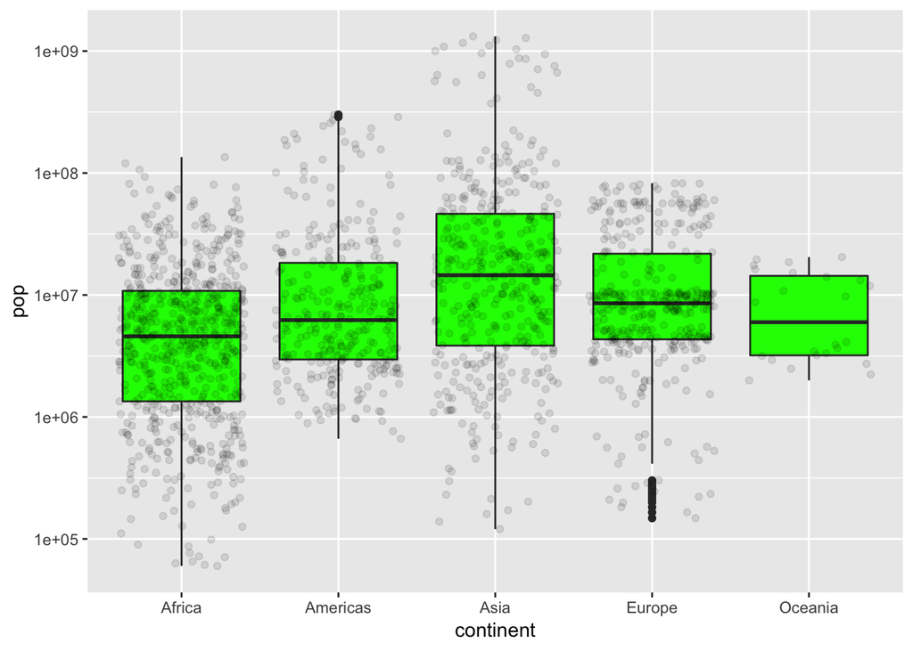

```r
ggplot(gapminder, aes(continent, pop)) +
  scale_y_log10() +
  geom_boxplot(fill = "green") +
  geom_jitter(alpha=.1)
```

Create a violin plot of gdpPercap per continent

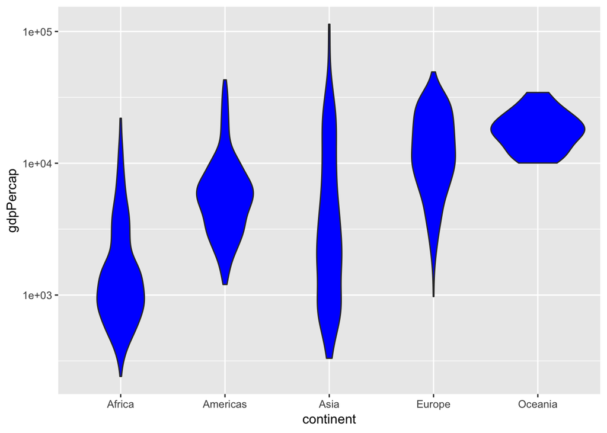

```r
ggplot(gapminder, aes(continent, gdpPercap)) +
  scale_y_log10() +
  geom_violin(fill = "blue")
```

Filter data for only Asian countries.

```r
gapminder %>%
  filter(continent == "Asia")
```

```
## # A tibble: 396 x 6
##    country     continent  year lifeExp      pop gdpPercap
##    <fct>       <fct>     <int>   <dbl>    <int>     <dbl>
##  1 Afghanistan Asia       1952    28.8  8425333      779.
##  2 Afghanistan Asia       1957    30.3  9240934      821.
##  3 Afghanistan Asia       1962    32.0 10267083      853.
##  4 Afghanistan Asia       1967    34.0 11537966      836.
##  5 Afghanistan Asia       1972    36.1 13079460      740.
##  6 Afghanistan Asia       1977    38.4 14880372      786.
##  7 Afghanistan Asia       1982    39.9 12881816      978.
##  8 Afghanistan Asia       1987    40.8 13867957      852.
##  9 Afghanistan Asia       1992    41.7 16317921      649.
## 10 Afghanistan Asia       1997    41.8 22227415      635.
## # ... with 386 more rows
```

Filter data for only Asian countries with population > 5,000,000

```r
gapminder %>%
  filter(pop > 5000000) %>%
  filter(continent == "Asia")
```

```
## # A tibble: 279 x 6
##    country     continent  year lifeExp      pop gdpPercap
##    <fct>       <fct>     <int>   <dbl>    <int>     <dbl>
##  1 Afghanistan Asia       1952    28.8  8425333      779.
##  2 Afghanistan Asia       1957    30.3  9240934      821.
##  3 Afghanistan Asia       1962    32.0 10267083      853.
##  4 Afghanistan Asia       1967    34.0 11537966      836.
##  5 Afghanistan Asia       1972    36.1 13079460      740.
##  6 Afghanistan Asia       1977    38.4 14880372      786.
##  7 Afghanistan Asia       1982    39.9 12881816      978.
##  8 Afghanistan Asia       1987    40.8 13867957      852.
##  9 Afghanistan Asia       1992    41.7 16317921      649.
## 10 Afghanistan Asia       1997    41.8 22227415      635.
## # ... with 269 more rows
```

Only present the gdpPercap and population for this subset of data

```r
gapminder %>%
  filter(pop > 5000000) %>%
  filter(continent == "Asia") %>%
  select(country, year, gdpPercap, pop)
```

```
## # A tibble: 279 x 4
##    country      year gdpPercap      pop
##    <fct>       <int>     <dbl>    <int>
##  1 Afghanistan  1952      779.  8425333
##  2 Afghanistan  1957      821.  9240934
##  3 Afghanistan  1962      853. 10267083
##  4 Afghanistan  1967      836. 11537966
##  5 Afghanistan  1972      740. 13079460
##  6 Afghanistan  1977      786. 14880372
##  7 Afghanistan  1982      978. 12881816
##  8 Afghanistan  1987      852. 13867957
##  9 Afghanistan  1992      649. 16317921
## 10 Afghanistan  1997      635. 22227415
## # ... with 269 more rows
```

Arrange this data in order from lowest to highest pop

```r
gapminder %>%
  filter(pop > 5000000) %>%
  filter(continent == "Asia")%>%
  select(country, year, gdpPercap, pop) %>%
  arrange(pop)
```

```
## # A tibble: 279 x 4
##    country           year gdpPercap     pop
##    <fct>            <int>     <dbl>   <int>
##  1 Hong Kong, China  1982    14561. 5264500
##  2 Jordan            2002     3845. 5307470
##  3 Cambodia          1957      434. 5322536
##  4 Iraq              1952     4130. 5441766
##  5 Yemen, Rep.       1957      805. 5498090
##  6 Israel            1997    20897. 5531387
##  7 Hong Kong, China  1987    20038. 5584510
##  8 Saudi Arabia      1967    16903. 5618198
##  9 Syria             1967     1882. 5680812
## 10 Hong Kong, China  1992    24758. 5829696
## # ... with 269 more rows
```

Filter this data for years 1995-2005

```r
gapminder %>%
  filter(pop > 5000000) %>%
  filter(continent == "Asia")%>%
  filter(year>1995 & year<2005)%>%
  select(country, year, gdpPercap, pop) %>%
  arrange(pop)
```

```
## # A tibble: 51 x 4
##    country           year gdpPercap      pop
##    <fct>            <int>     <dbl>    <int>
##  1 Jordan            2002     3845.  5307470
##  2 Israel            1997    20897.  5531387
##  3 Israel            2002    21906.  6029529
##  4 Hong Kong, China  1997    28378.  6495918
##  5 Hong Kong, China  2002    30209.  6762476
##  6 Cambodia          1997      734. 11782962
##  7 Cambodia          2002      896. 12926707
##  8 Syria             1997     4014. 15081016
##  9 Yemen, Rep.       1997     2117. 15826497
## 10 Syria             2002     4091. 17155814
## # ... with 41 more rows
```